# Importation des librairies

```python
import numpy as np
import pandas as pd
import matplotlib.pyplot as plt

import requests
import datetime

from bs4 import BeautifulSoup
from sklearn.linear_model import LinearRegression
from sklearn.model_selection import train_test_split
```

# Acquisition et chargement des données

Création d'un DataFrame df_days contenant tous les noms des urls à charger sur le site https://www.vendeeglobe.org/fr/classement

```python
# Création d'un Dataframe contenant tous les jours de naviguation du Vendée Globe.
# Chaque jour apparaît autant de fois qu'il a de classement publiés.
# Exemple : le 2021-03-05, il y a 2 classements publiés : 4h et 8h --> Ce jour apparaît deux fois.
s_days = pd.to_datetime(pd.Series([0]*5 + [i//6 for i in range(6,704)], name='Jours'),
                        unit='D',
                        origin=pd.Timestamp('2020-11-08'))

# Ajout de tous les classements publiés chaque jour.
df_days = pd.DataFrame(s_days.astype(str))
df_days['Classements publiés'] = ['12:02:00', '14:00:00', '15:00:00', '17:00:00', '21:00:00'] \
                                + ['04:00:00', '08:00:00', '11:00:00', '14:00:00', '17:00:00', '21:00:00']*116 \
                                + ['04:00:00', '08:00:00']

# Concatenation des 2 premières colonnes pour avoir une date sous la forme YYYY-mm-jj HH:MM:SS.
df_days['Date'] = df_days['Jours'] + ' ' + df_days['Classements publiés']
df_days['Date'] = df_days['Date'].apply(lambda x: datetime.datetime.strptime(x, "%Y-%m-%d %H:%M:%S"))

# Création de l'url à charger pour chaque classement publiés.
url = 'https://www.vendeeglobe.org/fr/classement/'
df_days['Url'] = df_days['Date'].apply(lambda x: x.strftime(url + "%Y%m%d_%H%M%S"))

# Chargements des données html avec Request puis Beautiful Soup.
df_days['Soup html'] = df_days['Url'].apply(lambda x: BeautifulSoup(requests.get(x).content))

# Modification de l'index.
df_days = df_days.set_index('Date')

df_days
```

| Date | Jours | Classements publiés | Url | Soup html |
| --- | --- | --- | --- | --- |
| 2020-11-08 12:02:00 | 2020-11-08 | 12:02:00 | https://www.vendeeglobe.org/fr/classement/2020... | [html, [\n, [\n, <meta charset="utf-8"/>, \n, ... |
| 2020-11-08 14:00:00 | 2020-11-08 | 14:00:00 | https://www.vendeeglobe.org/fr/classement/2020... | [html, [\n, [\n, <meta charset="utf-8"/>, \n, ... |
| 2020-11-08 15:00:00 | 2020-11-08 | 15:00:00 | https://www.vendeeglobe.org/fr/classement/2020... | [html, [\n, [\n, <meta charset="utf-8"/>, \n, ... |
| 2020-11-08 17:00:00 | 2020-11-08 | 17:00:00 | https://www.vendeeglobe.org/fr/classement/2020... | [html, [\n, [\n, <meta charset="utf-8"/>, \n, ... |
| 2020-11-08 21:00:00 | 2020-11-08 | 21:00:00 | https://www.vendeeglobe.org/fr/classement/2020... | [html, [\n, [\n, <meta charset="utf-8"/>, \n, ... |
| ... | ... | ... | ... | ... |
| 2021-03-04 14:00:00 | 2021-03-04 | 14:00:00 | https://www.vendeeglobe.org/fr/classement/2021... | [html, [\n, [\n, <meta charset="utf-8"/>, \n, ... |
| 2021-03-04 17:00:00 | 2021-03-04 | 17:00:00 | https://www.vendeeglobe.org/fr/classement/2021... | [html, [\n, [\n, <meta charset="utf-8"/>, \n, ... |
| 2021-03-04 21:00:00 | 2021-03-04 | 21:00:00 | https://www.vendeeglobe.org/fr/classement/2021... | [html, [\n, [\n, <meta charset="utf-8"/>, \n, ... |
| 2021-03-05 04:00:00 | 2021-03-05 | 04:00:00 | https://www.vendeeglobe.org/fr/classement/2021... | [html, [\n, [\n, <meta charset="utf-8"/>, \n, ... |
| 2021-03-05 08:00:00 | 2021-03-05 | 08:00:00 | https://www.vendeeglobe.org/fr/classement/2021... | [html, [\n, [\n, <meta charset="utf-8"/>, \n, ... |

703 rows × 4 columns

Création d'une copie du DataFrame, afin de pouvoir travailler avec sans risquer de perdre les données.

```python
df = df_days.copy()

# Suppression de certaines colonnes inutiles.
del df['Classements publiés']
del df['Jours']
```

# Préparation des données

Afin de pouvoir post-traiter n'importe quel classement publié du Vendée Globe, j'utilise une fonction post-traitement qui prend en argument une date comprise entre la date du départ et la date de l'arrivée du premier skippeur et qui renvoie un Dataframe contenant les informations principales obtenues sur leur site.

On s'arrête à la date de la première arrivée car le format change à la suite de cette date.

```python
def post_traitement(date):
    """
    Créer un DataFrame contenant toutes les information des skippeurs pour une date donnée.

    Exemple de date : '2020-11-17 14:00:00'
    """
    soup_test = df.loc[date, 'Soup html']
    table = soup_test.find('table')

    # Initialisation d'un Dataframe contenant toutes les informations pour un classemebt publié.
    df_skippers = pd.DataFrame([],
                              columns=['Date', 'Classement', 'Skipper', 'Bateau', 'Foils',
                                       'Vitesse', 'Vmg', 'Cap', 'Lat', 'Long', 'Distance Arrivée',
                                      'Distance Leader', 'Distance Poursuivant'])

    # La colonne Soup_ est temporaire.
    # Elle permet d'enregistrer les données de BeautifullSoup avant de les post-traiter.
    df_skippers['Soup_'] = table.find_all('tr', {'class':"ranking-row rankings__item"})

    # Classement.
    df_skippers['Classement'] = df_skippers['Soup_'].apply(
        lambda x: x.find('td', {'class':"row-number m--firstline"}).text)

    # Calcul du nombre d'abandon.
    try:
        nb_abd = df_skippers['Classement'].value_counts()['ABD']
    except:
        nb_abd = 0

    try:
        nb_nl = df_skippers['Classement'].value_counts()['NL']
    except:
        nb_nl = 0

    nb_abd =nb_abd + nb_nl

    # Nouvel index.
    #df_skippers = df_skippers.set_index('Classement')

    # Nom des skippers.
    df_skippers['Skipper'] = df_skippers['Soup_'].apply(
        lambda x: ' '.join(x.find('td', {'class':"row-skipper"}).text[:-len(x.find('td', {'class':"row-skipper"}).find('div').text+'\n')].split()))

    # Bateau des skippers.
    df_skippers['Bateau'] = df_skippers['Soup_'].apply(
        lambda x: x.find('td', {'class':"row-skipper"}).find('div').text)

    # Foils.
    df_skippers['Foils'] = df_skippers['Soup_'].apply(
        lambda x: x.find('td', {'title':"Foils"}).text)

    # Vitesse.
    # Prendre en compte le fait qu'un skipper a abandonné.
    df_skippers.loc[:str(32-nb_abd),'Vitesse'] = df_skippers.loc[:str(32-nb_abd),'Soup_'].apply(
        lambda x: ' '.join(x.find('td', {'title':"Vitesse"}).text.split()[2:]))

    # VMC.
    df_skippers.loc[:str(32-nb_abd),'Vmg'] = df_skippers.loc[:str(32-nb_abd),'Soup_'].apply(
        lambda x: x.find('td', {'title':"VMC"}).text)

    # Cap.
    df_skippers.loc[:str(32-nb_abd),'Cap'] = df_skippers.loc[:str(32-nb_abd),'Soup_'].apply(
        lambda x: x.find('td', {'title':"Cap"}).text)

    # Lat/Long.
    df_skippers.loc[:str(32-nb_abd),'Lat'] = df_skippers.loc[:str(32-nb_abd),'Soup_'].apply(
        lambda x: ' '.join(x.find('td', {'title':"Lat/Long"}).text.split()[:3]))

    df_skippers.loc[:str(32-nb_abd),'Long'] = df_skippers.loc[:str(32-nb_abd),'Soup_'].apply(
        lambda x: ' '.join(x.find('td', {'title':"Lat/Long"}).text.split()[3:]))

    # Distance à l'arrivée.
    df_skippers.loc[:str(32-nb_abd),'Distance Arrivée'] = df_skippers.loc[:str(32-nb_abd),'Soup_'].apply(
        lambda x: ' '.join(x.find('td', {'title':"Dist. à l'arrivée"}).text.split()[2:]))

    # Distance au leader.
    df_skippers.loc[:str(32-nb_abd),'Distance Leader'] = df_skippers.loc[:str(32-nb_abd),'Soup_'].apply(
        lambda x: ' '.join(x.find('td', {'title':"Au leader"}).text.split()[2:]))

    # Distance au poursuivant.
    df_skippers.loc[:str(32-nb_abd),'Distance Poursuivant'] = df_skippers.loc[:str(32-nb_abd),'Soup_'].apply(
        lambda x: ' '.join(x.find('td', {'title':"Au poursuivant"}).text.split()[2:]))


    del df_skippers['Soup_']

    # Date.
    df_skippers['Date'] = date

    return df_skippers
```

Exemple d'application de la fonction pour une date donnée.

```python
post_traitement('2020-11-09 17:00:00')
```

|  | Date | Classement | Skipper | Bateau | Foils | Vitesse | Vmg | Cap | Lat | Long | Distance Arrivée | Distance Leader | Distance Poursuivant |
| --- | --- | --- | --- | --- | --- | --- | --- | --- | --- | --- | --- | --- | --- |
| 0 | 2020-11-09 17:00:00 | 1 | Damien SEGUIN | GROUPE APICIL | Non | 20.02 km/h | 10.8 nds | 206° | 44° 44'11'' N | 7° 59'25'' O | 44508.56 km | 0 km | 19.21 km |
| 1 | 2020-11-09 17:00:00 | 2 | Maxime SOREL | V and B-MAYENNE | Non | 19.52 km/h | 10.44 nds | 211° | 44° 59'59'' N | 8° 11'52'' O | 44527.64 km | 19.21 km | 3.17 km |
| 2 | 2020-11-09 17:00:00 | 3 | Jean LE CAM | Yes We Cam! | Non | 20.46 km/h | 10.99 nds | 209° | 45° 1'46'' N | 8° 11'37'' O | 44530.97 km | 22.37 km | 6.61 km |
| 3 | 2020-11-09 17:00:00 | 4 | Benjamin DUTREUX | OMIA - WATER FAMILY | Non | 20.19 km/h | 10.85 nds | 211° | 45° 4'2'' N | 8° 6'14'' O | 44537.45 km | 28.98 km | 0.46 km |
| 4 | 2020-11-09 17:00:00 | 5 | Romain ATTANASIO | PURE - Best Western® | Non | 19.83 km/h | 10.7 nds | 209° | 45° 1'31'' N | 7° 57'43'' O | 44538.01 km | 29.45 km | 4.32 km |
| 5 | 2020-11-09 17:00:00 | 6 | Nicolas TROUSSEL | CORUM L'EPARGNE | Oui | 20.74 km/h | 11.02 nds | 212° | 45° 27'26'' N | 9° 17'22'' O | 44542.27 km | 33.76 km | 14.22 km |
| 6 | 2020-11-09 17:00:00 | 7 | Jérémie BEYOU | CHARAL | Oui | 20.76 km/h | 11.18 nds | 206° | 45° 35'24'' N | 9° 16'24'' O | 44556.53 km | 47.99 km | 2.26 km |
| 7 | 2020-11-09 17:00:00 | 8 | Stéphane LE DIRAISON | TIME FOR OCEANS | Oui | 19.46 km/h | 10.51 nds | 206° | 45° 12'37'' N | 7° 53'43'' O | 44558.75 km | 50.24 km | 0.91 km |
| 8 | 2020-11-09 17:00:00 | 9 | Sam DAVIES | INITIATIVES-COEUR | Oui | 19.52 km/h | 10.29 nds | 215° | 45° 30'18'' N | 8° 51'36'' O | 44559.68 km | 51.15 km | 6.22 km |
| 9 | 2020-11-09 17:00:00 | 10 | Kevin ESCOFFIER | PRB | Oui | 21.3 km/h | 11.48 nds | 206° | 45° 37'59'' N | 9° 6'0'' O | 44565.97 km | 57.37 km | 0.93 km |
| 10 | 2020-11-09 17:00:00 | 11 | Alex THOMSON | HUGO BOSS | Oui | 19.19 km/h | 10.2 nds | 213° | 45° 32'35'' N | 8° 44'57'' O | 44566.9 km | 58.3 km | 0.8 km |
| 11 | 2020-11-09 17:00:00 | 12 | Charlie DALIN | APIVIA | Oui | 20.71 km/h | 11.14 nds | 207° | 45° 40'22'' N | 9° 10'58'' O | 44567.64 km | 59.1 km | 6.56 km |
| 12 | 2020-11-09 17:00:00 | 13 | Yannick BESTAVEN | Maître CoQ IV | Oui | 18.24 km/h | 9.63 nds | 215° | 45° 35'58'' N | 8° 41'49'' O | 44574.12 km | 65.65 km | 2.82 km |
| 13 | 2020-11-09 17:00:00 | 14 | Clarisse CREMER | BANQUE POPULAIRE X | Non | 19.41 km/h | 10.27 nds | 214° | 45° 37'23'' N | 8° 41'2'' O | 44576.9 km | 68.47 km | 2.72 km |
| 14 | 2020-11-09 17:00:00 | 15 | Isabelle JOSCHKE | MACSF | Oui | 18.83 km/h | 9.99 nds | 213° | 45° 39'24'' N | 8° 42'33'' O | 44579.68 km | 71.19 km | 3 km |
| 15 | 2020-11-09 17:00:00 | 16 | Thomas RUYANT | LinkedOut | Oui | 18.78 km/h | 10.12 nds | 205° | 45° 53'7'' N | 9° 25'39'' O | 44582.64 km | 74.19 km | 0.52 km |
| 16 | 2020-11-09 17:00:00 | 17 | Armel TRIPON | L'OCCITANE EN PROVENCE | Oui | 18.59 km/h | 10.03 nds | 203° | 45° 50'42'' N | 9° 15'38'' O | 44583.2 km | 74.71 km | 1.19 km |
| 17 | 2020-11-09 17:00:00 | 18 | Didac COSTA | ONE PLANET ONE OCEAN | Non | 18.67 km/h | 9.92 nds | 198° | 45° 18'58'' N | 7° 28'46'' O | 44584.49 km | 75.89 km | 0.35 km |
| 18 | 2020-11-09 17:00:00 | 19 | Boris HERRMANN | SEAEXPLORER - YACHT CLUB DE MONACO | Oui | 17.61 km/h | 9.32 nds | 214° | 45° 46'34'' N | 8° 57'29'' O | 44584.68 km | 76.25 km | 2.74 km |
| 19 | 2020-11-09 17:00:00 | 20 | Sébastien SIMON | ARKEA PAPREC | Oui | 17.71 km/h | 9.4 nds | 213° | 45° 49'0'' N | 9° 0'31'' O | 44587.46 km | 78.99 km | 1.48 km |
| 20 | 2020-11-09 17:00:00 | 21 | Manuel COUSIN | GROUPE SÉTIN | Non | 18.35 km/h | 9.91 nds | 207° | 45° 27'50'' N | 7° 45'14'' O | 44588.94 km | 80.47 km | 9.93 km |
| 21 | 2020-11-09 17:00:00 | 22 | Louis BURTON | BUREAU VALLEE 2 | Oui | 19.46 km/h | 10.51 nds | 203° | 45° 59'3'' N | 9° 12'54'' O | 44598.94 km | 90.4 km | 6.74 km |
| 22 | 2020-11-09 17:00:00 | 23 | Miranda MERRON | CAMPAGNE DE FRANCE | Non | 16.83 km/h | 9.08 nds | 207° | 45° 37'8'' N | 7° 43'23'' O | 44605.61 km | 97.14 km | 1.24 km |
| 23 | 2020-11-09 17:00:00 | 24 | Giancarlo PEDOTE | PRYSMIAN GROUP | Oui | 18.28 km/h | 9.77 nds | 210° | 45° 54'30'' N | 8° 39'56'' O | 44606.9 km | 98.38 km | 2.69 km |
| 24 | 2020-11-09 17:00:00 | 25 | Pip HARE | MEDALLIA | Non | 17.76 km/h | 9.52 nds | 197° | 45° 37'34'' N | 7° 37'31'' O | 44609.49 km | 101.06 km | 19.83 km |
| 25 | 2020-11-09 17:00:00 | 26 | Clément GIRAUD | Compagnie du Lit / Jiliti | Non | 18.24 km/h | 9.66 nds | 198° | 45° 38'55'' N | 7° 8'53'' O | 44629.31 km | 120.9 km | 0.02 km |
| 26 | 2020-11-09 17:00:00 | 27 | Alan ROURA | LA FABRIQUE | Oui | 17.65 km/h | 9.51 nds | 206° | 46° 5'11'' N | 8° 31'15'' O | 44629.5 km | 120.92 km | 0.48 km |
| 27 | 2020-11-09 17:00:00 | 28 | Ari HUUSELA | STARK | Non | 13.85 km/h | 7.43 nds | 218° | 45° 41'45'' N | 7° 14'58'' O | 44629.87 km | 121.4 km | 11.8 km |
| 28 | 2020-11-09 17:00:00 | 29 | Alexia BARRIER | TSE - 4MYPLANET | Non | 17.89 km/h | 9.65 nds | 201° | 45° 55'29'' N | 7° 33'54'' O | 44641.72 km | 133.2 km | 4.7 km |
| 29 | 2020-11-09 17:00:00 | 30 | Arnaud BOISSIÈRES | LA MIE CÂLINE - ARTISANS ARTIPÔLE | Oui | 17 km/h | 9.12 nds | 196° | 46° 7'2'' N | 8° 3'21'' O | 44646.35 km | 137.9 km | 2.32 km |
| 30 | 2020-11-09 17:00:00 | 31 | Kojiro SHIRAISHI | DMG MORI Global One | Oui | 17.8 km/h | 9.6 nds | 199° | 46° 20'19'' N | 8° 45'7'' O | 44648.76 km | 140.21 km | 6.24 km |
| 31 | 2020-11-09 17:00:00 | 32 | Sébastien DESTREMAU | MERCI | Non | 15.39 km/h | 8.23 nds | 212° | 46° 7'13'' N | 7° 46'56'' O | 44655.05 km | 146.46 km | 345.75 km |
| 32 | 2020-11-09 17:00:00 | 33 | Fabrice AMEDEO | NEWREST - ART & FENÊTRES | Oui | 0 km/h | 0 nds | 0° | 46° 30'8'' N | 1° 47'25'' O | 45000.64 km | 492.21 km |  |

Création d'un DataFrame résultant de la conténation de tous les jours du Vendée Globe jusqu'à l'arrivée du premier Voilier.

```python
df_vg = post_traitement(df.index[0])

i = 1
while str(df.index[i]) != '2021-01-27 17:00:00': # Date de la première arrivée d'un skipper.
    df_vg = df_vg.append(post_traitement(df.index[i]))
    i += 1

df_vg = df_vg.reset_index(drop=True)

# Création d'un copie locale de ce dataframe, pour éviter de recharger par la suite toutes les url.
df_vg.to_pickle('df_vendee_globe.pkl')
```

```python
df_vg = pd.read_pickle('df_vendee_globe.pkl')

print(df_vg.shape)
df_vg
```

```
(15939, 13)
```

|  | Date | Classement | Skipper | Bateau | Foils | Vitesse | Vmg | Cap | Lat | Long | Distance Arrivée | Distance Leader | Distance Poursuivant |
| --- | --- | --- | --- | --- | --- | --- | --- | --- | --- | --- | --- | --- | --- |
| 0 | 2020-11-08 12:02:00 | 1 | Charlie DALIN | APIVIA | Oui | 0 km/h | 0 nds | 0° | 46° 30'8'' N | 1° 47'24'' O | 44997.3 km | 0 km |  |
| 1 | 2020-11-08 12:02:00 | 2 | Sébastien SIMON | ARKEA PAPREC | Oui | 0 km/h | 0 nds | 0° | 46° 30'8'' N | 1° 47'24'' O | 44997.3 km | 0 km |  |
| 2 | 2020-11-08 12:02:00 | 3 | Clarisse CREMER | BANQUE POPULAIRE X | Non | 0 km/h | 0 nds | 0° | 46° 30'8'' N | 1° 47'24'' O | 44997.3 km | 0 km |  |
| 3 | 2020-11-08 12:02:00 | 4 | Louis BURTON | BUREAU VALLEE 2 | Oui | 0 km/h | 0 nds | 0° | 46° 30'8'' N | 1° 47'24'' O | 44997.3 km | 0 km |  |
| 4 | 2020-11-08 12:02:00 | 5 | Miranda MERRON | CAMPAGNE DE FRANCE | Non | 0 km/h | 0 nds | 0° | 46° 30'8'' N | 1° 47'24'' O | 44997.3 km | 0 km |  |
| ... | ... | ... | ... | ... | ... | ... | ... | ... | ... | ... | ... | ... | ... |
| 15934 | 2021-01-27 14:00:00 | ABD | Sam DAVIES | INITIATIVES-COEUR | Oui | NaN | NaN | NaN | NaN | NaN | NaN | NaN | NaN |
| 15935 | 2021-01-27 14:00:00 | ABD | Sébastien SIMON | ARKEA PAPREC | Oui | NaN | NaN | NaN | NaN | NaN | NaN | NaN | NaN |
| 15936 | 2021-01-27 14:00:00 | ABD | Alex THOMSON | HUGO BOSS | Oui | NaN | NaN | NaN | NaN | NaN | NaN | NaN | NaN |
| 15937 | 2021-01-27 14:00:00 | ABD | Kevin ESCOFFIER | PRB | Oui | NaN | NaN | NaN | NaN | NaN | NaN | NaN | NaN |
| 15938 | 2021-01-27 14:00:00 | ABD | Nicolas TROUSSEL | CORUM L'EPARGNE | Oui | NaN | NaN | NaN | NaN | NaN | NaN | NaN | NaN |

15939 rows × 13 columns

Suppression des NaN dans le DataFrame : plus de 2000 lignes supprimées.

```python
df_vg = df_vg.dropna()
df_vg.shape
```

```
(13736, 13)
```

On a donc un DataFrame complet avec lequel on pourra effectuer nos analyses.

On pourra changer le type des colonnes (str/int/float) en fonction de ce que l'on veut faire, mais ce n'est pas utile pour le moment.

## Extraction des caractéristiques techniques de chacun des voiliers.

Chargement, dans un DataFrame, des données techniques de tous les voiliers du Vendée Globe à partir de l'url suivante : https://www.vendeeglobe.org/fr/glossaire.

```python
url_glossaire = 'https://www.vendeeglobe.org/fr/glossaire'
requests.get(url_glossaire)
soup_glossaire = BeautifulSoup(requests.get(url_glossaire).content)

skipper_items = soup_glossaire.find_all('div', {'class':"sv-u-1 sv-u-s-1-2 sv-u-m-1-3 sv-u-l-1-6"})

# Utilisation d'un dictionnaire avant d'écrire le Dataframe.
boats_dict = {}

for soup_boat in skipper_items:
    # Nom du skipper.
    boats_dict[soup_boat.find('h3', {'class':"boats-list__boat-name"}).text] = {
        'Skipper': soup_boat.find('span', {'class':"boats-list__skipper-name"}).text
    }

    # Autres données techniques.
    for soup_li in soup_boat.find_all('li'):
        boats_dict[soup_boat.find('h3', {'class':"boats-list__boat-name"}).text][soup_li.text.split(':')[0]] = soup_li.text.split(':')[1]

df_boats = pd.DataFrame(boats_dict)
df_boats
```

|  | NEWREST - ART & FENÊTRES | PURE - Best Western® | TSE - 4MYPLANET | Maître CoQ IV | CHARAL | LA MIE CÂLINE - ARTISANS ARTIPÔLE | BUREAU VALLEE 2 | ONE PLANET ONE OCEAN | GROUPE SÉTIN | BANQUE POPULAIRE X | ... | PRYSMIAN GROUP | LA FABRIQUE | LinkedOut | GROUPE APICIL | DMG MORI Global One | ARKEA PAPREC | V and B-MAYENNE | HUGO BOSS | L'OCCITANE EN PROVENCE | CORUM L'EPARGNE |
| --- | --- | --- | --- | --- | --- | --- | --- | --- | --- | --- | --- | --- | --- | --- | --- | --- | --- | --- | --- | --- | --- |
| Skipper | Fabrice AMEDEO | Romain ATTANASIO | Alexia BARRIER | Yannick BESTAVEN | Jérémie BEYOU | Arnaud BOISSIÈRES | Louis BURTON | Didac COSTA | Manuel COUSIN | Clarisse CREMER | ... | Giancarlo PEDOTE | Alan ROURA | Thomas RUYANT | Damien SEGUIN | Kojiro SHIRAISHI | Sébastien SIMON | Maxime SOREL | Alex THOMSON | Armel TRIPON | Nicolas TROUSSEL |
| Numéro de voile | FRA 56 | FRA 49 | FRA72 | 17 | 08 | FRA 14 | 18 | ESP 33 | FRA 71 | FRA30 | ... | ITA 34 | SUI07 | NaN | FRA1000 | JPN 11 | 4 | FRA53 | GBR 99 | 2 | FRA 6 |
| Anciens noms du bateau | No Way Back, Vento di Sardegna | Gitana Eighty, Synerciel, Newrest-Matmut | Famille Mary-Etamine du Lys, Initiatives Coeu... | Safran 2 - Des Voiles et Vous | NaN | Ecover3, Président, Gamesa, Kilcullen Voyager... | Banque Populaire VIII | Kingfisher - Educacion sin Fronteras - Forum ... | Paprec-Virbac2, Estrella Damm, We are Water, ... | Macif - SMA | ... | Saint-Michel - Virbac | Brit Air, Votre Nom autour du Monde, MACSF | NaN | Comme Un Seul Homme, DCNS | NaN | NaN | Le Souffle du Nord, Groupe Bel | NaN | NaN | NaN |
| Architecte | VPLP/Verdier | Bruce Farr Design | Marc Lombard | Verdier - VPLP | VPLP | Owen Clarke Design LLP - Clay Oliver | Verdier - VPLP | Owen Clarke Design | Bruce Farr Yacht Design | Verdier - VPLP | ... | VPLP - Verdier | Groupe Finot-Conq | Verdier | Groupe Finot-Conq | VPLP | Juan Kouyoumdjian | Verdier - VPLP | VPLP - Alex Thomson Racing (led by Pete Hobson) | Samuel Manuard | Juan Kouyoumdjian |
| Chantier | Persico Marine | Southern Ocean Marine (Nouvelle Zélande) | MAG France | CDK Technologies | CDK Technologies | Hakes Marine - Mer Agitée | CDK Technologies | Martens Yachts | Southern Ocean Marine (Nouvelle-Zélande) | CDK - Mer Agitée | ... | Multiplast | Multiplast | Persico | Multiplast | Multiplast | CDK Technologies / Assemblage | Indiana Yachting (Scarlino, Italie) | Carrington Boats | Black Pepper© | CDK technologies - Mer Agitée |
| Date de lancement | 01 Août 2015 | 08 Mars 2007 | 01 Mars 1998 | 12 Mars 2015 | 18 Août 2018 | 03 Août 2007 | 09 Juin 2015 | 02 Février 2000 | 02 Février 2007 | 01 Mars 2011 | ... | 02 Avril 2015 | 01 Août 2007 | 03 Septembre 2019 | 10 Août 2008 | 05 Septembre 2019 | 19 Juillet 2019 | 07 Septembre 2007 | 15 Août 2019 | 31 Janvier 2020 | 15 Mai 2020 |
| Longueur | 18,28 m | 18,28m | 18,28m | 18,28 m | 18,28 m | 18,28 m | 18,28 m | 18,28 m | 18,28 m | 18,28 m | ... | 18,28 m | 18,28 m | 18,28 m | 18,28 m | 18,28 m | 18,28 m | 18,28 m | 18,28 m | 18,28 m | 18,28 m |
| Largeur | 5,85 m | 5,80m | 5,54m | 5,80 m | 5,85 m | 5,65 m | 5,80 m | 5,30 m | 5,80 m | 5,70 m | ... | 5,80 m | 5,90 m | 5,85 m | 5,85 m | 5,85 m | 5,70 m | 5,50 m | 5,40 m | 5,50 m | 5,70 m |
| Tirant d'eau | 4,50 m | 4,50m | 4,50m | 4,50 m | 4,50 m | 4,50 m | 4,50 m | 4,50 m | 4,50 m | 4,5 m | ... | 4,5 m | 4,50 m | 4,50 m | 4,50 m | 4,50 m | 4,50 m | 4,50 m | 4,50 m | 4,50 m | 4,50 m |
| Déplacement (poids) | 7 t | 9t | 9t | 8 t | 8t | 7,9 tonnes | 7,6 t | 8,9 t | 9 t | 7,7 t | ... | 8 t | nc | 8 t | 8,5 t | 8 t | 8 t | 7,7 t | 7,7 t | 7,8 t | 7,9 t |
| Nombre de dérives | foils | 2 | 2 | foils | foils | foils | foils | 2 | 2 asymétriques | 2 | ... | foils | foils | foils | 2 | foils | foiler | 2 | foils | foils | foils |
| Hauteur mât | 29 m | 28m | 29 m | 29 m | 29 m | 29 m | 28 m | 26 m | 28,50 | 29 m | ... | 29 m | 27 m | 29 m | 29 m | 29 m | 29 m | 29 m | 29 m | 28 m | 27,30 m |
| Voile quille | monotype | acier forgé | acier | acier mécano soudé | acier | basculante avec vérin | acier | acier | basculante sur vérin hydraulique | acier forgé | ... | acier forgé | carbone | acier forgé | acier forgé | acier forgé | Inox usiné | acier | acier forgé | acier forgé | NaN |
| Surface de voiles au près | 320 m2 | 280 m2 | 260 m2 | 310 m2 | 320 m2 | 300 m² | 300 m2 | 240 m2 | 270 m2 | 340 m2 | ... | 300 m2 | 290 m2 | 350 m2 | 350 m2 | 320 m2 | 260 m2 | 365 m2 | 330 m2 | 270 m2 | 270 m2 |
| Surface de voiles au portant | 570 m2 | 560 m2 | 580 m2 | 550 m2 | 600 m2 | 610 m² | 600 m2 | 470 m2 | 560 m2 | 570 m2 | ... | 600 m2 | 580 m2 | 560 m2 | 610 m2 | 580 m2 | 600 m2 | 700 m2 | 630 m2 | 535 m2 | 535 m2 |

15 rows × 33 columns

Création d'une copie locale de ce dataframe, afin de ne pas avoir à recharger la page si besoin.

```python
df_boats.to_pickle('df_glossaire.pkl')
```

Pour le moment, il n'y a aucune utilité à merger les deux DataFrames, cela impliquerait alors une enorme répétition des caractéritiques techniques.

# Analyses

Dans cette partie nous allons effectuer plusieurs analyses afin de mieux commprendre les données et de mieux les illsutrer également.

## Corrélation et régression linéaire entre le classement (rang) et la vitesse utile (VMG) des voiliers.

Il faut tout d'abord changer le type des colonnes utilisées pour cette étude : classement et vmg.

Par la même occasion, on modifiera le type des autres colonnes numériques, mais qui sont écrites en str et avec les unités.

```python
df_vg['Classement'] = df_vg['Classement'].astype(int)

# Le split premet de récupérer uniquement la valeur numérique sans l'unité.
df_vg[['Vitesse_num',
       'Vmg_num',
       'Distance Arrivée num',
       'Distance Leader num']] = df_vg[['Vitesse',
                                        'Vmg',
                                        'Distance Arrivée',
                                        'Distance Leader']].applymap(lambda x: x.split()[0]).astype(float)

# On assigne des nouvelles variables pour plus de simplicité qui contiennent respectivement tous les classements
# et tous les VMG pour chaque skipper sur toute la durée de la course.
df_classement = df_vg.groupby('Skipper')['Classement'].apply(np.array)
df_vmg = df_vg.groupby('Skipper')['Vmg_num'].apply(np.array)
```

Il est intéressant de comparer l'évolution du classement des 3 premiers skippeurs arrivant en tête du classement final (après conpensation effectuée) : Yannick BESTAVEN, Charlie DALIN, Louis BURTON

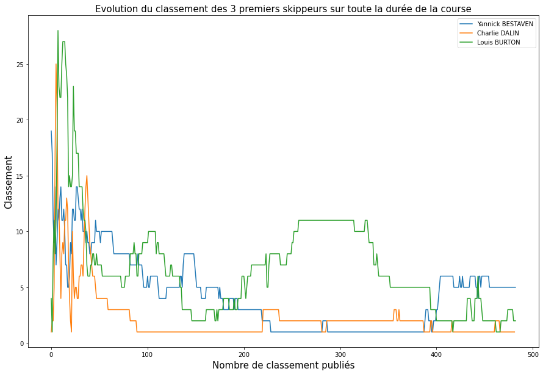

```python
plt.figure(figsize=(15,10)) # Uniquement les 3 premiers

plt.plot(df_classement['Yannick BESTAVEN'], label='Yannick BESTAVEN')
plt.plot(df_classement['Charlie DALIN'], label='Charlie DALIN')
plt.plot(df_classement['Louis BURTON'], label='Louis BURTON')

plt.title('Evolution du classement des 3 premiers skippeurs sur toute la durée de la course',
         fontsize=15)
plt.xlabel('Nombre de classement publiés', fontsize=15)
plt.ylabel('Classement', fontsize=15)
plt.legend()

plt.show()
```

```python
df_classement['Yannick BESTAVEN'][-1]
```

```
5
```

On remarque que Yannick BESTAVEN apparaît comme 5 ème à passer la ligne d'arrivée alors qu'il est le vainqueur de ce Vendée Globe.

Cela s'explique par la compensation qui lui a été appliquée au passage de la ligne d'arrivée pour avoir participer au sauvetage de Kevin Escoffier durant la course.

La figure ci-dessous nous montre la vitesse moyenne de 3 skippeurs diiférents tout au long des classements publiés.

Pour essayer de contratster au plus ce graphique, j'ai pris le skippeurs en tête au classement final : Yannick BESTAVEN, un skippeur du milieu de tableau Maxime SOREL et le dernier ayant passé la ligne d'arrivée : Ari HUUSELA.

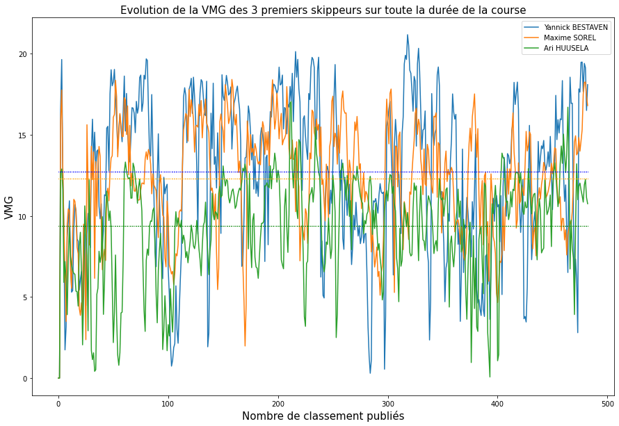

```python
plt.figure(figsize=(15,10))

plt.plot(df_vmg['Yannick BESTAVEN'], label='Yannick BESTAVEN')
plt.plot(df_vmg['Maxime SOREL'], label='Maxime SOREL')
plt.plot(df_vmg['Ari HUUSELA'], label='Ari HUUSELA')

# Affichage de la moyenne VMG totale pour chacun des 3 skippeurs.
plt.plot(np.linspace(df_vmg['Yannick BESTAVEN'].mean(),
            df_vmg['Yannick BESTAVEN'].mean(),
            len(df_vmg['Yannick BESTAVEN'])), ',',color='blue')

plt.plot(np.linspace(df_vmg['Maxime SOREL'].mean(),
            df_vmg['Maxime SOREL'].mean(),
            len(df_vmg['Maxime SOREL'])), ',',color='orange')

plt.plot(np.linspace(df_vmg['Ari HUUSELA'].mean(),
            df_vmg['Ari HUUSELA'].mean(),
            len(df_vmg['Ari HUUSELA'])), ',',color='green')

plt.title('Evolution de la VMG des 3 premiers skippeurs sur toute la durée de la course',
         fontsize=15)
plt.xlabel('Nombre de classement publiés', fontsize=15)
plt.ylabel('VMG', fontsize=15)
plt.legend()

plt.show()
```

Sur ces 3 skippers opposés en terme de classement, on remarque graphiquement que plus la VMG moyenne totale est haute et plus leur classement est faible.

Pour l'analyse qui suit, nous allons uniquement nous concentrer sur le skippeur ayant passé le premier la ligne d'arrivée : Charlie DALIN, sans compter donc les compensations de temps qui ont été attribuées à Yannick BESTAVEN.

Cela pour éviter toute mauvaise interprétation des résultats.

```python
# Régression linéaire entre le classement et la vitesse utile VMG pour 75% des données.
X = df_vmg['Charlie DALIN'].reshape(-1,1)
Y = df_classement['Charlie DALIN']

X_train, X_test, Y_train, Y_test = train_test_split(X, Y, test_size=0.20)

skl_lm = LinearRegression()

skl_lm.fit(X_train, Y_train)

Y_pred = skl_lm.predict(X_test) # Prédiction
```

Evaluation du modèle avec le coefficient de détermination $R^2$

```python
print('Le coefficient de détermination est : {}'.format(round(skl_lm.score(X_train, Y_train), 2)))
```

```
Le coefficient de détermination est : 0.02
```

On obtient un coefficient de determination trè!s faible ce qui veut dire qu'il n'y a peu de corrélation entre le classement et la VMG.

On peut tout de même afficher le résultat de la régression sur un graphe.

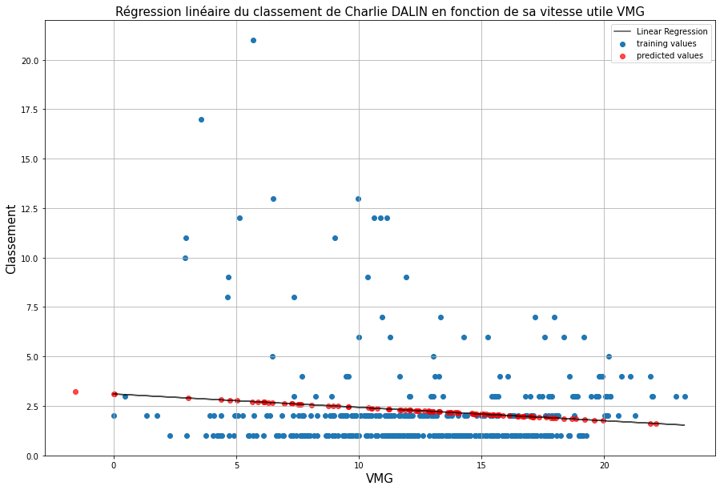

```python
plt.figure(figsize=(15,10))

plt.scatter(X_train, Y_train, label='training values')
plt.scatter(X_test, Y_pred, color='red', alpha=0.7, label='predicted values')
plt.plot(X_train, skl_lm.predict(X_train), alpha=0.7, label='Linear Regression', c='k')

plt.title('Régression linéaire du classement de Charlie DALIN en fonction de sa vitesse utile VMG',
         fontsize=15)
plt.xlabel('VMG', fontsize=15)
plt.ylabel('Classement', fontsize=15)
plt.legend()
plt.grid()

plt.show()
```

## Impact de la présence d'un foil sur le classement et la vitesse des voiliers.

Il est possible de faire une première analyse avec uniquement la connaissance d'une présence ou non de foils sur le bateau.

```python
df_vg.groupby(['Foils']).agg({'Skipper': lambda x: x.nunique(),
                              'Vitesse_num': np.mean})
```

| Foils | Skipper | Vitesse_num |
| --- | --- | --- |
| Non | 14 | 22.604254 |
| Oui | 19 | 25.075901 |

Cette analyse, vague, nous permet de voir que la présence d'un foil pemret de gagner en moyenne 2,4 km/h sur la course.

En poussant l'analyse, on peut également comparer les résultats en fonction des nombres de dérives, ce qui nécessite de faire un merge entre les Dataframe des classements et des caractéristiques techniques.

```python
df_foils = pd.DataFrame(df_boats.loc['Nombre de dérives ']).reset_index()

df_merge = pd.merge(left=df_vg,
                    right=df_foils,
                    left_on='Bateau',
                    right_on='index',
                    how='inner')
```

```python
df_merge.groupby(['Foils', 'Nombre de dérives ']).agg({'Skipper': lambda x: x.nunique(),
                                                      'Vitesse_num': np.mean})
```

| Foils | Nombre de dérives | Skipper | Vitesse_num |
| --- | --- | --- | --- |
| Non | 2 | 13 | 22.648384 |
|  | 2 asymétriques | 1 | 22.036501 |
| Oui | foiler | 1 | 25.768365 |
|  | foils | 18 | 25.059898 |

## Visualisation de la distance parcourue par voilier.

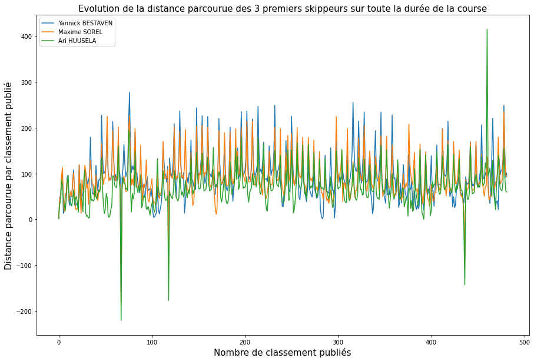

```python
df_distance = df_vg.groupby('Skipper')['Distance Arrivée num'].apply(np.array)

plt.figure(figsize=(15,10))

# Calcul de la différence entre le classement publié C(t) et celui à l'instant t+1 C(t+1)
plt.plot(df_distance['Yannick BESTAVEN'][:-1] - df_distance['Yannick BESTAVEN'][1:],
         label='Yannick BESTAVEN')
plt.plot(df_distance['Maxime SOREL'][:-1] - df_distance['Maxime SOREL'][1:],
         label='Maxime SOREL')
plt.plot(df_distance['Ari HUUSELA'][:-1] - df_distance['Ari HUUSELA'][1:],
         label='Ari HUUSELA')


plt.title('Evolution de la distance parcourue des 3 premiers skippeurs sur toute la durée de la course',
         fontsize=15)
plt.xlabel('Nombre de classement publiés', fontsize=15)
plt.ylabel('Distance parcourue par classement publié', fontsize=15)
plt.legend()

plt.show()
```

On peut remarquer qu'en général, Yannick BESTAVEN parcours plus de distances que les deux autres skippeurs.

```python
! jupyter nbconvert --to html "projet_vendee_globe.ipynb"
```

```
[NbConvertApp] Converting notebook projet_vendee_globe.ipynb to html
[NbConvertApp] Writing 1281841 bytes to projet_vendee_globe.html
```